# Data Visualization - Mini-Project 1

Jeffrey DuBois `jeffreydubois0258@floridapoly.edu`

```r
library(writexl)
library(tidyverse)
```

# Data Import

We will start by importing the dataset

```r
ncua_df <- read.csv("../data/NCUA_Data.csv") #This is the actual dataset (pre-merged)
acctnames <- read.csv("../data/AcctDesc.csv") #This file contains descriptions for each column which will be easier to use
```

# Data Wrangling

```r
names(ncua_df)[50:55]
```

```
[1] "ACCT_100" "ACCT_300" "ACCT_340" "ACCT_380" "ACCT_386" "ACCT_387"
```

We can see from this subset of the names() output of the original dataset that the columns are named in reference to their Account Number, this comes from the NCUA Call Report and is essentially meaningless unless you memorize the useful account numbers.

```r
ncol(ncua_df)
```

```
[1] 2324
```

And with over 2,300 columns (almost all named in the same format), it can be easy to mix up the columns.

```r
head(acctnames[,1:2])
```

|  | Account | AcctName |
| --- | --- | --- |
| 1 | Acct_001 | Amount - Total Other Loans (Purchased or to non-members) |
| 2 | Acct_002 | Amount of Leases Receivable |
| 3 | Acct_003 | Loans Held for Sale |
| 4 | Acct_007 | Land and Building |
| 5 | Acct_008 | Other Fixed Assets |
| 6 | Acct_009 | Other Assets |

Before we do any analysis I want to update these column names to be more useful. The acctname dataframe contains the Account Numbers and Names for each field, I intend to use this to update the column names in the ncua_df dataframe.

```r
temp_df <- ncua_df

names(temp_df)<-acctnames$AcctName[match(toupper(names(ncua_df)), toupper(acctnames$Account))]

names(temp_df)[is.na(names(temp_df))]<-names(ncua_df)[is.na(names(temp_df))]

ncua_df <- temp_df

rm(temp_df)
```

The code above will replace the Account Numbers with names, it might not be the most efficent way, but it works and it quick.

```r
names(ncua_df)[50:55]
```

```
[1] "Total Gross Income"                                                    "Provision for Loan & Lease Losses"                                     "Interest on Borrowed Money"
[4] "Dividends on Shares (Includes dividends earned during current period)" "Amount of Total Other RE Loans/Lines of Credit"                        "Amount All Other MBLs (Non-agriculture)"
```

We can see the same columns tested above now have names instead of account numbers, this will make further analysis much easier.

# Data Summary by State

With the data wrangling out of the way we can summarize the data to get a better idea of what the file contains.

```r
dim(ncua_df)
```

```
[1] 5136 2324
```

This file contains records on 5,136 Credit Unions Across the United States.

```r
state_group <- ncua_df %>%
  group_by(STATE,) %>%
  summarize(n = n()) %>%
  arrange(desc(n))
state_group
```

| STATE | n |
| --- | --- |
| TX | 433 |
| PA | 344 |
| NY | 314 |
| CA | 286 |
| OH | 237 |
| IL | 229 |
| MI | 211 |
| LA | 163 |
| MA | 151 |
| IN | 147 |

[output cut: 44 more lines]

The table above shows there are Credit Unions in 54 “States” (The additional 4 states are DC, Guam, Puerto Rico and the Virgin Islands) and Texas is the most common state for Credit Unions.

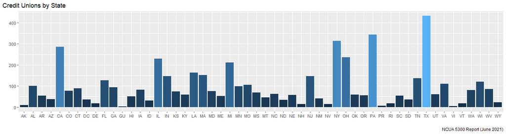

The plot above is just a visualization of the data in the previous table.

Now the graph above makes some intuitive sense, the states known to have higher populations (California, Texas, New York, etc.) have more credit unions. What would be interesting to see would be this value normalized by Asset Size.

```r
state_group_assets <- ncua_df %>%
  group_by(STATE,) %>%
  summarize(n = n(), assets = sum(`TOTAL ASSETS`)) %>%
  arrange(desc(n))
state_group_assets
```

| STATE | n | assets |
| --- | --- | --- |
| TX | 433 | 135026235040 |
| PA | 344 | 66068076474 |
| NY | 314 | 109506220619 |
| CA | 286 | 266958681359 |
| OH | 237 | 40870857795 |
| IL | 229 | 61644131462 |
| MI | 211 | 90905052840 |
| LA | 163 | 15127174945 |
| MA | 151 | 48682878299 |
| IN | 147 | 38479814678 |

[output cut: 44 more lines]

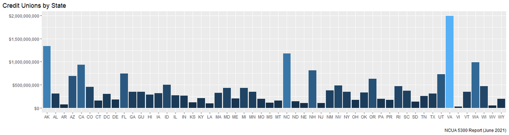

The table and plot above show Virgina’s Credit Unions, on average, have a larger asset size than other states, but I have a suspicion that this is due to Navy Federal Credit Union. Navy Federal is the largest credit union in the nation. We need to view this data as a box and whisker plot to get a better idea of the distribution of asset size of credit unions by state.

To make the plot more useful we could try viewing it in a logarithmnic scale.

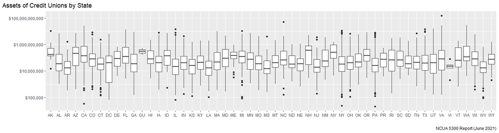

Before moving on from this plot I would like to add a horizontal line for the national median to get a better idea for each state’s difference.

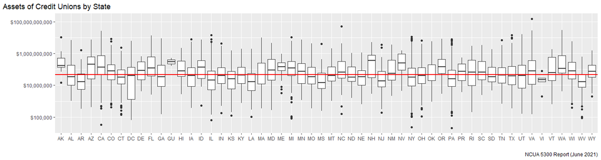

The plot above can be easily replicated for any other metric, such as depsoits and loans:

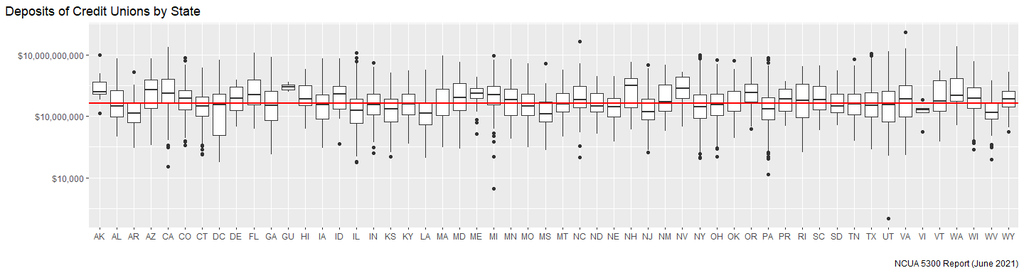

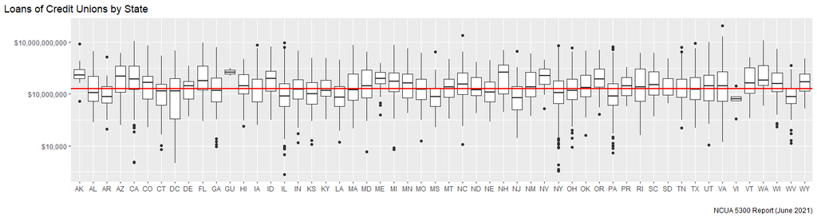

The plots above are quite similar to the asset plot and this is to be expected, Credit Unions all have a similar principle, they take in members’ deposits to use as funding for loans to other members.

This reminds me of a scene from my favorite movie, *It’s a Wonderful Life*.

[figure not shown]

# Use of Shares in Lending

To better show the relationship between deposits and loans we can do a scatterplot.

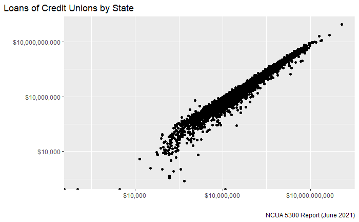

```r
ggplot(ncua_df, aes(x=`Total Amount of Shares and Deposits`, y=`Total amount of Loans and Leases`))+
  geom_point()+
  labs(title="Loans of Credit Unions by State", caption = "NCUA 5300 Report (June 2021)", x="", y="")+
  guides(fill = FALSE)+
  theme(plot.title.position = "plot")+
  scale_y_log10(labels = scales::dollar)+
  scale_x_log10(labels = scales::dollar)
```

```r
sum(ncua_df$`Total amount of Loans and Leases`)/sum(ncua_df$`Total Amount of Shares and Deposits`)
```

[output not shown]

```r
ggplot(ncua_df, aes(x=`Total Amount of Shares and Deposits`, y=`Total amount of Loans and Leases`/`Total Amount of Shares and Deposits`))+
  geom_point(size = 0.5, color = "Blue")+
  geom_smooth(method=lm, color = "Black")+
  geom_hline(yintercept = 1, color="Red")+
  labs(title="Relationship of Deposits to Loans", caption = "NCUA 5300 Report (June 2021)", x="Deposits", y="Percent of Deposits Currently on Loan")+
  guides(fill = FALSE)+
  theme(plot.title.position = "plot")+
  scale_y_continuous(labels = scales::percent)+
  scale_x_log10(labels = scales::dollar)+
  coord_cartesian(ylim = c(0,1))
```

[output not shown]

# Operating Expenses per Dollar of Deposit

In an attempt to show the increased operating efficiency of credit unions with increased deposits I decided to take a look at Non-Interest Expenses. These would be expenses such as Employee Compensation, Office Occupancy Expenses and Promotional Expenses. Essentially these would be expenses not paid to the members in the form of dividends and instead serve to allow the operation of the credit union.

As a quick graph, lets see what the makeup of Non-Interest Expenses are nationally

```r
expenses <- ncua_df %>%
  select (`Employee Compensation and Benefits`,`Office Occupancy Expense`,`Office Operations Expense`,`Educational and Promotional Expense`,`Loan Servicing Expense`,`Professional and Outside Services`,`Miscellaneous Operating Expenses`) %>%
  colSums() %>%
  data.frame()

names(expenses)<-"YTD Amount"
expenses$Category <- row.names(expenses)
row.names(expenses) <- NULL

expenses<-arrange(expenses,desc(`YTD Amount`))

total <- sum(expenses$`YTD Amount`)

ggplot(data = expenses, aes(x="", y=`YTD Amount`, fill=Category))+
  geom_bar(stat="identity", width=1) +
  coord_polar("y", start=0)+
  theme_void()+
  geom_text(aes(label = paste0(round(`YTD Amount`/total,2)*100, "%")), position = position_stack(vjust=0.5)) +
  labs(x = NULL, y = NULL, fill = NULL)
```

[output not shown]

I am surprised that office operations is higher than office occupancy.

With the concept of Non-Interest Expenses established, we can now look at efficiency.

There are a few ways of measuring efficiency and the NCUA has a few standards such as an efficiency ratio which is a measure of income over expenses, but for my purpose I want to see efficiency from a member’s point of view. As previously mentioned I did this by comparing a credit unions total deposits to their non-interest expenses.

```r
ggplot(ncua_df, aes(x=`Total Amount of Shares and Deposits`, y=`Total Non-Interest Expense`))+
  geom_point(size = 0.5, color = "Blue")+
  geom_smooth(method=lm, color = "Black")+
  labs(title="Relationship of Non-Interest Expenses to Deposits", caption = "NCUA 5300 Report (June 2021)", x="Deposits", y="Non-Interest Expenses YTD")+
  guides(fill = FALSE)+
  theme(plot.title.position = "plot")+
  scale_y_log10(labels = scales::dollar)+
  scale_x_log10(labels = scales::dollar)
```

[output not shown]

```r
ggplot(filter(ncua_df,`Total Amount of Shares and Deposits`>10000), aes(x=`Total Amount of Shares and Deposits`, y=`Total Non-Interest Expense`/`Total Amount of Shares and Deposits`))+
  geom_point(size = 0.5, color = "Blue")+
  geom_smooth(method=lm, color = "Black")+
  labs(title="Relationship of Non-Interest Expenses to Deposits", caption = "NCUA 5300 Report (June 2021)", x="Deposits", y="Operating Effiency per Dollar of Deposit")+
  guides(fill = FALSE)+
  theme(plot.title.position = "plot")+
  scale_y_continuous(labels = scales::dollar)+
  scale_x_log10(labels = scales::dollar)+
  coord_cartesian(ylim = c(0,0.05))
```

[output not shown]